# Accelerated SGD - Explained

```python
        # -------------------------------------------------------------------
        # "Fake" optimizer step - does NOT actually update model weights
        # -------------------------------------------------------------------
        # sched.optimizer is the optimizer that this scheduler is attached to.
        # We stored the optimizer when we created the scheduler:
        #   sched = lr_scheduler.CosineAnnealingLR(opt, 100)
        # So sched.optimizer IS the same object as 'opt'.
        #
        # Calling optimizer.step() normally updates model weights based on
        # gradients. But here, there are NO gradients (we never called
        # loss.backward()), so this call does effectively nothing.
        #
        # WHY DO WE CALL IT THEN?
        # Starting from PyTorch 1.1, if you call scheduler.step() WITHOUT
        # first calling optimizer.step(), PyTorch prints a warning:
        #   "Detected call of `lr_scheduler.step()` before `optimizer.step()`"
        # This warning exists to catch a common bug in training loops.
        # By calling optimizer.step() first (even though it's a no-op here),
        # we suppress this warning and keep our output clean.
        sched.optimizer.step()  # Fake optimizer step (just to suppress warning)

        # -------------------------------------------------------------------
        # Step the scheduler - THIS is what actually changes the learning rate
        # -------------------------------------------------------------------
        # sched.step() tells the scheduler to advance by one step and compute
        # the NEW learning rate based on its internal formula.
        #
        # For CosineAnnealingLR, this:
        #   1. Increments the internal step counter (sched.last_epoch += 1)
        #   2. Computes new LR using the cosine formula:
        #      LR = eta_min + 0.5*(base_lr - eta_min)*(1 + cos(π * step / T_max))
        #   3. Updates the optimizer's learning rate:
        #      opt.param_groups[0]['lr'] = new_LR
        #
        # After this call, the optimizer will use the NEW learning rate for
        # any subsequent parameter updates.
        sched.step()  # Advance the scheduler by one step

        # -------------------------------------------------------------------
        # Record the new learning rate after this step
        # -------------------------------------------------------------------
        # get_last_lr() now returns the learning rate that was just computed
        # by the step() call above.
        #
        # We append it to our list so we can plot the entire trajectory later.
        lrs.append(sched.get_last_lr())  # Record the LR after stepping

    # -----------------------------------------------------------------------
    # Plot the learning rate trajectory
    # -----------------------------------------------------------------------
    # plt.plot(lrs) creates a line chart where:
    #   - X-axis: the index in the list (0, 1, 2, ..., steps) = step number
    #   - Y-axis: the learning rate at that step
    #
    # Note: each element in 'lrs' is actually a LIST (e.g., [0.006]),
    # not a single number. matplotlib handles this gracefully - it will
    # plot each parameter group's LR as a separate line. Since we only
    # have one parameter group, we get one line.
    plt.plot(lrs)

    # Add axis labels so the plot is self-explanatory.
    # Without labels, someone looking at the plot wouldn't know what the
    # axes represent.
    plt.xlabel('Step')           # X-axis: training step number
    plt.ylabel('Learning Rate')  # Y-axis: learning rate value

    # Add a title to the plot.
    # This tells the viewer exactly what schedule is being visualized.
    plt.title('Cosine Annealing Schedule')


# ===========================================================================
# SECTION 5: Visualize 110 Steps of Cosine Annealing
# ===========================================================================
#
# Now we actually CALL our visualization function to see the cosine
# annealing schedule in action.
#
# WHY 110 STEPS (NOT 100)?
# Our scheduler has T_max=100, meaning one complete half-cosine cycle
# takes 100 steps. By visualizing 110 steps, we get to see:
#
#   Steps 0-100:  The learning rate smoothly decreases from 0.006 to 0
#                 following the cosine curve. This is the "annealing" phase.
#
#   Steps 100-110: What happens AFTER the cycle completes? The cosine
#                  function is periodic, so the LR starts INCREASING again!
#                  This is the beginning of a "warm restart" - the LR
#                  bounces back up from 0 toward the base LR.
#
# This is a deliberate choice by the notebook author to show students
# that CosineAnnealingLR is PERIODIC - it doesn't just stop at 0.
# Understanding this behavior is important because:
#   - If your training has exactly T_max steps: LR decays to 0 (good!)
#   - If your training has MORE than T_max steps: LR bounces back up
#     (this might be surprising and could cause training instability
#     if you didn't expect it)
#   - This periodic behavior is actually the basis for "Cosine Annealing
#     with Warm Restarts" (SGDR), a popular technique where you
#     intentionally let the LR cycle up and down multiple times.
#
# EXPECTED PLOT:
# The plot should show:
#   - A smooth cosine-shaped decrease from 0.006 to ~0 over steps 0-100
#   - Then the curve turns upward from step 100 onward
#   - The curve is NOT linear - it decreases slowly at first, then faster
#     in the middle, then slowly again near the bottom (characteristic
#     cosine shape)

print("\nVisualizing Cosine Annealing Schedule (110 steps, T_max=100):")
print("=" * 60)
print("Watch how the LR decreases smoothly from 0.006 to 0 over 100 steps,")
print("then starts increasing again after step 100 (the periodic behavior).")
print("=" * 60)

sched_lrs(sched, 110)

# Show the plot on screen.
# plt.show() is needed when running as a script (in Jupyter notebooks,
# plots are displayed automatically). Without this call, the plot would
# be created in memory but never displayed.
plt.show()
```

```
Base learning rates (starting LR for the cosine schedule):
[0.006]

Current learning rate (before any scheduler steps):
[0.006]

Visualizing Cosine Annealing Schedule (110 steps, T_max=100):
============================================================
Watch how the LR decreases smoothly from 0.006 to 0 over 100 steps,
then starts increasing again after step 100 (the periodic behavior).
============================================================
```

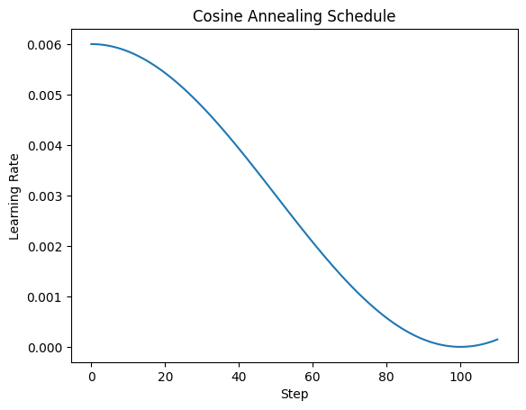

```python
# ===========================================================================
# SUMMARY OF WHAT WE LEARNED
# ===========================================================================
#
# 1. CREATING A SCHEDULER:
#    sched = lr_scheduler.CosineAnnealingLR(optimizer, T_max)
#    - Attach it to an existing optimizer
#    - T_max = number of steps for one half-cosine cycle
#
# 2. INSPECTING A SCHEDULER:
#    sched.base_lrs      → Starting learning rate(s) [list]
#    sched.get_last_lr()  → Current learning rate(s) [list]
#
# 3. STEPPING A SCHEDULER:
#    sched.step()  → Advance by one step, compute new LR
#    - Must call AFTER optimizer.step() in training
#    - Each call updates the optimizer's learning rate
#
# 4. COSINE ANNEALING BEHAVIOR:
#    - Smooth cosine-shaped decrease from base_lr to eta_min (default 0)
#    - Periodic: after T_max steps, LR increases back up (warm restart)
#    - Slower decay at start and end, faster in the middle
#    - Set T_max = total training steps to get monotonic decrease
#
# 5. KEY INSIGHT:
#    The cosine shape spends MORE time at lower learning rates than a
#    linear decay would. This is beneficial because fine-tuning at the
#    end of training benefits from extended time at low LR.
#
# NEXT IN THE NOTEBOOK:
# After understanding the scheduler, the notebook builds callback classes
# (BaseSchedCB, BatchSchedCB, EpochSchedCB) to integrate schedulers into
# the fast.ai training loop, and then demonstrates the powerful 1cycle
# training policy using OneCycleLR.
# ===========================================================================
```

[figure not shown]

# Understanding `sched_lrs` — A Visualization Tool, Not a Training Tool

## The Core Question

When you look at the `sched_lrs` function, a natural question arises:

> "This function creates a list of learning rate values using the cosine scheduler and plots them... but it never feeds those values back into any training loop. So how is it actually used? What's the point?"

This is an excellent observation, and the answer reveals an important pattern in deep learning workflows.

## What `sched_lrs` Actually Does

`sched_lrs` is a **visualization-only / exploration-only** tool. It is **NOT** part of the training pipeline. Here is exactly what happens when you call it:

```
sched_lrs(sched, 110)
```

1. It records the current learning rate
2. It calls `sched.step()` 110 times in a loop (with no real training happening — no data, no gradients, no weight updates)
3. After each step, it records the new learning rate into a list
4. It plots that list as a line chart
5. **That's it.** The list of LR values is never returned, never stored, never passed to any training function. They get plotted and then thrown away.

No model is being trained. No weights are being updated. The `sched.optimizer.step()` call inside the function is a **fake** optimizer step — it exists only to suppress a PyTorch warning that would otherwise print if you call `sched.step()` without calling `optimizer.step()` first.

## So Why Does This Function Exist?

It exists for the same reason you might sketch a blueprint before building a house — **you want to see what your plan looks like before committing to it.**

In deep learning, a training run can take minutes, hours, or even days. If you pick a bad learning rate schedule, you waste all that time. So the standard practice is:

1. **Create the scheduler**
2. **Visualize it first** ← this is what `sched_lrs` does
3. **Only then** wire it into your actual training loop

By calling `sched_lrs(sched, 110)`, you can answer questions like:

- Does the LR decrease smoothly or does it drop suddenly?
- What happens after `T_max` steps — does it stay at zero or bounce back up?
- Is the decay too fast? Too slow?
- How much time does the model spend at high LR vs low LR?

For example, with `T_max=100` and `steps=110`, the plot reveals that cosine annealing is **periodic** — after reaching 0 at step 100, the LR starts climbing back up. If you didn't know this, you might accidentally train for 120 steps thinking the LR stays at 0, when in reality it's rising again. This preview saves you from that surprise.

## Where the Scheduler Is ACTUALLY Used in Training

The real integration happens **later in the notebook**, in Parts 8 and 9. Here is the flow:

### Step 1: Build Scheduler Callbacks (Part 8)

The notebook creates callback classes that call `sched.step()` inside the real training loop:

```
class BatchSchedCB(BaseSchedCB):
    """Step the scheduler after every BATCH."""
    def after_batch(self, learn):
        self._step(learn)

class EpochSchedCB(BaseSchedCB):
    """Step the scheduler after every EPOCH."""
    def after_epoch(self, learn):
        self._step(learn)
```

These callbacks are the bridge between the scheduler and the training loop. When attached to a `Learner`, they automatically call `sched.step()` at the right time — either after every batch or after every epoch.

### Step 2: Train with the Scheduler (Parts 8-9)

Now the scheduler is wired into real training:

```
# Create scheduler (as a partial — not instantiated yet)
tmax = 3 * len(dls.train)  # Total batches across 3 epochs
sched = partial(lr_scheduler.CosineAnnealingLR, T_max=tmax)

# Attach it via BatchSchedCB
xtra = [BatchSchedCB(sched), rec]

# Train — the scheduler now changes LR after every batch
learn = TrainLearner(model, dls, F.cross_entropy, lr=2e-2, cbs=cbs+xtra, opt_func=optim.AdamW)
learn.fit(3)
```

During this training:

- After every batch, `BatchSchedCB.after_batch()` fires
- It calls `sched.step()`, which computes the new LR using the cosine formula
- The optimizer's learning rate is updated
- The next batch uses the new (lower) learning rate

**This** is where the scheduler actually affects training. Not in `sched_lrs`.

## The Full Workflow in the Notebook

Here is the complete sequence, showing where `sched_lrs` fits:

```
Part 7: Understanding Schedulers
│
├── Create a scheduler: sched = CosineAnnealingLR(opt, 100)
├── Inspect it:         sched.base_lrs, sched.get_last_lr()
├── VISUALIZE it:       sched_lrs(sched, 110)          ← You are here
│                       (preview only, no training)
│
Part 8: Integrating Schedulers into Training
│
├── Build BaseSchedCB   (creates scheduler when training starts)
├── Build BatchSchedCB  (calls sched.step() after every batch)
├── Build EpochSchedCB  (calls sched.step() after every epoch)
├── Build RecorderCB    (records LR during training for plotting)
│
├── TRAIN with batch-wise cosine annealing
│   └── sched.step() is called after every batch by BatchSchedCB
│
├── TRAIN with epoch-wise cosine annealing
│   └── sched.step() is called after every epoch by EpochSchedCB
│
Part 9: 1cycle Training
│
├── TRAIN with OneCycleLR (the most powerful scheduler)
│   └── LR goes: low → high → very low
│   └── Momentum goes: high → low → high (opposite!)
│   └── Both change after every batch via BatchSchedCB
```

## Analogy

Think of it like a thermostat schedule for your house:

- **`sched_lrs`** is like opening the thermostat app and looking at the temperature schedule for the week — "Oh, it'll be 72°F in the morning, drop to 65°F at night, then warm up again." You're just **looking** at the plan. The house temperature doesn't change just because you looked at it.
- **`BatchSchedCB` / `EpochSchedCB`** is like the thermostat actually being connected to the furnace and AC. Now the schedule **controls** the real temperature in real time.

`sched_lrs` lets you inspect the plan. The callbacks execute the plan.

## Key Takeaway

`sched_lrs` is a **dry-run visualization tool**. It answers the question: *"What will my learning rate look like over N steps?"* without spending any compute on actual training. The scheduler is wired into real training later through callback classes (`BatchSchedCB`, `EpochSchedCB`) that call `sched.step()` inside the training loop. This two-step pattern — visualize first, then train — is standard practice in deep learning to avoid wasting time on bad hyperparameter choices.

The cosine curve:

- Starts at the initial LR
- Smoothly decreases to 0 at T_max steps
- Then increases back up (if you continue past T_max)

### 🎮 Interactive: schedule explorer — cosine & 1cycle, live

The cosine curve above, plus the two schedules coming later — with the actual `opt.step(); sched.step()` mechanic.

**What to try**

- **Hover/click the curve** to inspect any step's lr; drag **T_max** and see the shape stretch (T_max must match your `sched.step()` count!).
- Press the **`opt.step(); sched.step()` ▸** button repeatedly — the readout is literally `get_last_lr()` advancing.
- Tab 2 previews **batch-wise vs epoch-wise** stepping (smooth glide vs staircase) — you'll build those callbacks shortly.
- Tab 3 is **OneCycleLR**: drag `pct_start` and `max_lr`, and note momentum running the *inverse* cycle.

```python
# ============================================================================
# INTERACTIVE -- run this cell. It loads ./interactive_viz/lr_schedule_explorer.html
# at full width, sized to fit the visualization (setup cell near the top required).
# Keep the 'interactive_viz' folder in the SAME directory as this notebook.
# ============================================================================
show_viz("interactive_viz/lr_schedule_explorer.html", height="800px")
```

[interactive chart not shown]

## Part 8: Scheduler Callbacks

We need callbacks to integrate schedulers into our training loop.

```python
#|export
class BaseSchedCB(Callback):
    """
    Base class for scheduler callbacks.

    Creates the scheduler when training starts and provides
    a method to step it.

    Args:
        sched: A scheduler class (not instance) like lr_scheduler.CosineAnnealingLR
    """
    def __init__(self, sched):
        self.sched = sched  # Store scheduler class

    def before_fit(self, learn):
        # Create scheduler instance with the learner's optimizer
        self.schedo = self.sched(learn.opt)

    def _step(self, learn):
        """Step the scheduler if we're training (not validating)"""
        if learn.training:
            self.schedo.step()
```

```python
#|export
class BatchSchedCB(BaseSchedCB):
    """
    Step the scheduler after every batch.

    Use this for schedulers that should update per-batch,
    like OneCycleLR or CosineAnnealingLR with T_max = total_batches.
    """
    def after_batch(self, learn):
        self._step(learn)
```

# `BaseSchedCB` — Explained

## The Code

```
class BaseSchedCB(Callback):
    def __init__(self, sched):
        self.sched = sched              # Store scheduler CLASS (a callable)

    def before_fit(self, learn):
        self.schedo = self.sched(learn.opt)  # Create scheduler INSTANCE

    def _step(self, learn):
        if learn.training:
            self.schedo.step()           # Advance the schedule
```

## Is `self.sched` a Callable?

Yes. `self.sched` is a **class** (not an instance), and in Python, classes are callables — calling a class creates an instance of it. So when you pass `lr_scheduler.CosineAnnealingLR` to `BaseSchedCB`, you're passing the class itself:

```
# This is what you pass in:
sched_cb = BatchSchedCB(lr_scheduler.CosineAnnealingLR)

# self.sched is now the CLASS lr_scheduler.CosineAnnealingLR
# It's not an instance yet — it's the blueprint
```

Then later in `before_fit`, calling `self.sched(learn.opt)` is the same as:

```
self.schedo = lr_scheduler.CosineAnnealingLR(learn.opt)
```

This creates the actual scheduler instance. The reason we can't create it earlier is that the optimizer (`learn.opt`) doesn't exist until `learn.fit()` is called — so we have to delay construction until `before_fit`.

## Why Does This Class Exist?

The problem: we want to plug a learning rate scheduler into the training loop, but we don't control the loop directly. The `Learner` class runs the loop internally. We need to call `sched.step()` somewhere in this loop, but we can't modify the Learner. The solution is **callbacks** — the Learner calls hook methods like `before_fit()`, `after_batch()`, and `after_epoch()` on all registered callbacks at the appropriate points.

`BaseSchedCB` handles the boilerplate that every scheduler callback needs:

1. Store the scheduler class
2. Create the scheduler instance when training starts (because that's when the optimizer exists)
3. Provide a `_step` method that only advances the schedule during training (not validation)

## How It's Actually Used in the Notebook

`BaseSchedCB` is never used directly. It's a **base class** — its subclasses decide *when* to step the scheduler:

### `BatchSchedCB` — Steps After Every Batch

```
class BatchSchedCB(BaseSchedCB):
    def after_batch(self, learn):
        self._step(learn)
```

This is the one used in the notebook. The learning rate changes after every single batch.

### The Full Training Code

```
# 1. Define the scheduler as a partial (class + its arguments, but not created yet)
sched = partial(lr_scheduler.CosineAnnealingLR, T_max=100)

# 2. Wrap it in a BatchSchedCB callback
xtra = [BatchSchedCB(sched), rec]

# 3. Train — the callback handles everything automatically
learn = TrainLearner(model, dls, F.cross_entropy, lr=2e-2,
                     cbs=cbs+xtra, opt_func=optim.AdamW)
learn.fit(3)
```

## The Exact Call Chain: How `learn.fit()` Triggers `after_batch()`

This is the key question: **how does calling `learn.fit(3)` end up calling `BatchSchedCB.after_batch()`?** There's no obvious link in the code. Let's trace through every step using the actual source code from `learner.py`.

### The Players

There are four pieces of code involved:

```
# 1. run_cbs — loops through all callbacks and calls a method on each
def run_cbs(cbs, method_nm, learn=None):
    for cb in sorted(cbs, key=attrgetter('order')):
        method = getattr(cb, method_nm, None)
        if method is not None: method(learn)

# 2. with_cbs — a decorator that wraps a function with before_X / after_X calls
class with_cbs:
    def __init__(self, nm): self.nm = nm
    def __call__(self, f):
        def _f(o, *args, **kwargs):
            try:
                o.callback(f'before_{self.nm}')   # Call before_X on all callbacks
                f(o, *args, **kwargs)              # Run the actual function
                o.callback(f'after_{self.nm}')     # Call after_X on all callbacks
            except globals()[f'Cancel{self.nm.title()}Exception']: pass
            finally: o.callback(f'cleanup_{self.nm}')
        return _f

# 3. Learner.callback — just calls run_cbs with the learner's callbacks
class Learner:
    def callback(self, method_nm): run_cbs(self.cbs, method_nm, self)

# 4. BatchSchedCB — our scheduler callback
class BatchSchedCB(BaseSchedCB):
    def after_batch(self, learn):
        self._step(learn)
```

### The Chain, Step by Step

Let's say `learn.cbs` contains `[DeviceCB(), MetricsCB(), BatchSchedCB(sched)]`.

#### Step 1: `learn.fit(3)` creates the optimizer and starts the loop

```
def fit(self, n_epochs=1, train=True, valid=True, cbs=None, lr=None):
    self.n_epochs = n_epochs
    self.epochs = range(n_epochs)
    if lr is None: lr = self.lr
    if self.opt_func: self.opt = self.opt_func(self.model.parameters(), lr)
    self._fit(train, valid)  # ← goes here next
```

#### Step 2: `self._fit()` is decorated with `@with_cbs('fit')`

```
@with_cbs('fit')
def _fit(self, train, valid):
    for self.epoch in self.epochs:
        if train: self.one_epoch(True)
        if valid: torch.no_grad()(self.one_epoch)(False)
```

Because of the `@with_cbs('fit')` decorator, what actually runs is:

```
# The decorator wraps _fit like this:
self.callback('before_fit')      # ← calls before_fit() on ALL callbacks
self._fit(train, valid)          #   (this is where BaseSchedCB creates the scheduler)
self.callback('after_fit')       # ← calls after_fit() on ALL callbacks
```

**This is where `BaseSchedCB.before_fit(learn)` gets called**, which creates the scheduler:

```
# Inside BaseSchedCB:
def before_fit(self, learn):
    self.schedo = self.sched(learn.opt)  # Scheduler is created here
```

#### Step 3: Inside `_fit`, for each epoch, `one_epoch()` calls `_one_epoch()`

```
def one_epoch(self, training):
    self.model.train(training)
    self.dl = self.dls.train if training else self.dls.valid
    self._one_epoch()  # ← goes here next
```

#### Step 4: `_one_epoch()` is decorated with `@with_cbs('epoch')`

```
@with_cbs('epoch')
def _one_epoch(self):
    for self.iter, self.batch in enumerate(self.dl):
        self._one_batch()  # ← processes each batch
```

The decorator wraps this as:

```
self.callback('before_epoch')
# ... loop over batches, calling _one_batch() for each ...
self.callback('after_epoch')
```

#### Step 5: `_one_batch()` is decorated with `@with_cbs('batch')` — THIS IS THE KEY

```
@with_cbs('batch')
def _one_batch(self):
    self.predict()
    self.callback('after_predict')
    self.get_loss()
    self.callback('after_loss')
    if self.training:
        self.backward()
        self.callback('after_backward')
        self.step()
        self.callback('after_step')
        self.zero_grad()
```

Because of `@with_cbs('batch')`, what actually executes is:

```
self.callback('before_batch')    # Call before_batch() on all callbacks
# --- the actual batch processing ---
self.predict()
self.get_loss()
self.backward()
self.step()                      # optimizer.step() — update weights
self.zero_grad()
# --- end of batch processing ---
self.callback('after_batch')     # ← THIS IS THE LINE THAT TRIGGERS THE SCHEDULER
```

#### Step 6: `self.callback('after_batch')` calls `run_cbs`

```
# Learner.callback:
def callback(self, method_nm):
    run_cbs(self.cbs, method_nm, self)
```

So `self.callback('after_batch')` becomes:

```
run_cbs(self.cbs, 'after_batch', self)
```

#### Step 7: `run_cbs` loops through all callbacks and calls `after_batch` on each

```
def run_cbs(cbs, method_nm, learn=None):
    for cb in sorted(cbs, key=attrgetter('order')):
        method = getattr(cb, method_nm, None)  # Look for .after_batch on this callback
        if method is not None:                  # If it exists...
            method(learn)                       # ...call it, passing the learner
```

When it reaches `BatchSchedCB` in the callback list:

```
method = getattr(BatchSchedCB_instance, 'after_batch', None)
# method is now the BatchSchedCB.after_batch function
method(learn)  # Calls BatchSchedCB.after_batch(learn)
```

#### Step 8: `BatchSchedCB.after_batch` calls `_step`, which calls `schedo.step()`

```
class BatchSchedCB(BaseSchedCB):
    def after_batch(self, learn):
        self._step(learn)                  # inherited from BaseSchedCB

class BaseSchedCB(Callback):
    def _step(self, learn):
        if learn.training:
            self.schedo.step()             # Advance the cosine annealing schedule!
```

The learning rate is now updated for the next batch.

### The Complete Chain in One View

```
learn.fit(3)
  │
  ├── self.opt = self.opt_func(model.parameters(), lr)   # Create optimizer
  │
  └── self._fit()                           # Decorated with @with_cbs('fit')
        │
        ├── self.callback('before_fit')
        │     └── run_cbs(self.cbs, 'before_fit', self)
        │           └── BaseSchedCB.before_fit(learn)
        │                 └── self.schedo = self.sched(learn.opt)  ← SCHEDULER CREATED
        │
        └── for each epoch:
              └── self._one_epoch()         # Decorated with @with_cbs('epoch')
                    │
                    └── for each batch:
                          └── self._one_batch()   # Decorated with @with_cbs('batch')
                                │
                                ├── predict → loss → backward → opt.step → zero_grad
                                │
                                └── self.callback('after_batch')     ← THE TRIGGER
                                      │
                                      └── run_cbs(self.cbs, 'after_batch', self)
                                            │
                                            └── BatchSchedCB.after_batch(learn)
                                                  │
                                                  └── self._step(learn)
                                                        │
                                                        └── self.schedo.step()  ← LR UPDATED
```

### The Magic: `@with_cbs` Decorator

The entire connection between `learn.fit()` and `BatchSchedCB.after_batch()` exists because of the `@with_cbs('batch')` decorator on `_one_batch`. This decorator automatically calls `self.callback('after_batch')` after every batch finishes, which loops through all callbacks looking for any that have an `after_batch` method. `BatchSchedCB` has one, so it gets called.

The callback never needs to know about the Learner's internals, and the Learner never needs to know about the scheduler. The `@with_cbs` decorator is the bridge — it fires named events at specific points, and any callback that defines a method with the matching name gets called automatically.

This is the **Observer pattern** in software design: the Learner broadcasts events ("a batch just finished"), and any callback that's listening for that event gets notified. You can add or remove callbacks without changing the Learner, and add new functionality (like scheduling, logging, early stopping) just by writing a new callback class with the right method name.

## The Design Pattern: Why a Base Class?

The base class exists because *when* to step the scheduler is a separate concern from *how* to set it up:

[output not shown]

If you wanted an epoch-level scheduler, you'd just write:

```
class EpochSchedCB(BaseSchedCB):
    def after_epoch(self, learn):
        self._step(learn)
```

All the setup logic is inherited — you only specify the timing. This is the benefit of splitting it into a base class: the shared logic is written once, and subclasses are tiny one-liners that differ only in *when* they fire.

# Multiple Callbacks with the Same Method — Do All of Them Run?

## Short Answer

Yes, **all of them run**. If four callbacks define `before_fit`, all four get called, one after another.

## How It Works

The mechanism is `run_cbs`, which loops through **every** callback in the list and calls the method if it exists:

```
def run_cbs(cbs, method_nm, learn=None):
    for cb in sorted(cbs, key=attrgetter('order')):
        method = getattr(cb, method_nm, None)
        if method is not None: method(learn)  # Called on EVERY cb that has it
```

There's no early exit, no "first match wins." Every callback gets a chance. If a callback doesn't have the method (e.g., `RecorderCB` has no `before_batch`), `getattr` returns `None` and it's silently skipped. If it does have the method, it gets called.

## Concrete Example

Suppose your callbacks are:

```
cbs = [DeviceCB(), MetricsCB(), BatchSchedCB(sched), RecorderCB(lr=_lr)]
```

When `self.callback('before_fit')` fires during `learn.fit()`, `run_cbs` goes through each one:

```
self.callback('before_fit')
  │
  └── run_cbs(cbs, 'before_fit', learn)
        │
        ├── DeviceCB.before_fit(learn)      → moves model to GPU
        ├── MetricsCB.before_fit(learn)     → sets up metric tracking
        ├── BatchSchedCB.before_fit(learn)  → creates the scheduler instance
        └── RecorderCB.before_fit(learn)    → creates empty recording lists
```

All four run, one after another. None are skipped. The same applies to every other hook — `after_batch`, `after_epoch`, `before_batch`, etc. Every callback that defines the matching method gets called.

## Execution Order: The `order` Attribute

The callbacks are sorted by their `order` attribute before being called:

```
for cb in sorted(cbs, key=attrgetter('order')):
```

The default `order` is 0 (set in the base `Callback` class). If two callbacks both have `order = 0`, they run in the order they appear in the list. If you need one callback to run before another, you give it a lower `order`:

```
class Callback(): order = 0          # default

class ProgressCB(Callback):
    order = MetricsCB.order + 1      # runs AFTER MetricsCB
```

In this case, `MetricsCB` (order 0) computes the metrics first, then `ProgressCB` (order 1) displays them. The ordering ensures `ProgressCB` has data to display.

## What If Two Callbacks Conflict?

The system doesn't prevent conflicts. If two callbacks both try to modify `learn.lr` in `before_fit`, they'll both run and the second one wins (it overwrites what the first one set). This is by design — it's the user's responsibility to compose callbacks that make sense together, just like composing functions that don't step on each other's state.

## Summary

| Question | Answer |
| --- | --- |
| If 4 callbacks define `before_fit`, how many run? | All 4 |
| What if a callback doesn't define `before_fit`? | Silently skipped |
| What controls the order? | The `order` attribute (lower runs first) |
| Can one callback block another from running? | No (unless it raises a Cancel exception, which stops the *entire* phase, not just one callback) |

This is the core design of the callback system: every callback handles its own concern independently, they all coexist without knowing about each other, and they all get called at every hook point they've subscribed to.

```python
#|export
class HasLearnCB(Callback):
    """
    Callback that stores a reference to the learner.

    Useful for callbacks that need to access the learner
    outside of the standard callback methods.
    """
    def before_fit(self, learn):
        self.learn = learn  # Store learner reference

    def after_fit(self, learn):
        self.learn = None  # Clear reference
```

```python
#|export
class RecorderCB(Callback):
    """
    Record values during training for visualization.

    Pass a dictionary of name -> function pairs.
    Each function receives the callback and returns a value to record.

    Example:
        RecorderCB(lr=lambda cb: cb.pg['lr'])

    Args:
        **d: Named functions that return values to record
    """
    def __init__(self, **d):
        self.d = d  # Store the recording functions

    def before_fit(self, learn):
        # Create empty lists for each value to record
        self.recs = {k: [] for k in self.d}
        # Store reference to first param group (for easy LR access)
        self.pg = learn.opt.param_groups[0]

    def after_batch(self, learn):
        # Only record during training
        if not learn.training:
            return
        # Record each value
        for k, v in self.d.items():
            self.recs[k].append(v(self))  # Call function with self

    def plot(self):
        """Plot all recorded values."""
        for k, v in self.recs.items():
            plt.plot(v, label=k)
            plt.legend()
            plt.show()
```

```python
# Function to get learning rate from callback
def _lr(cb):
    """Extract learning rate from param group."""
    return cb.pg['lr']
```

# `RecorderCB.after_batch` — Explained

## The Full Code

```
class RecorderCB(Callback):
    def __init__(self, **d):
        self.d = d

    def before_fit(self, learn):
        self.recs = {k: [] for k in self.d}
        self.pg = learn.opt.param_groups[0]

    def after_batch(self, learn):
        if not learn.training:
            return
        for k, v in self.d.items():
            self.recs[k].append(v(self))

    def plot(self):
        for k, v in self.recs.items():
            plt.plot(v, label=k)
            plt.legend()
            plt.show()
```

## How `RecorderCB` Is Used in the Notebook

### Step 1: Define what to record

```
def _lr(cb):
    return cb.pg['lr']
```

This is a tiny function that takes a `RecorderCB` instance and reads the current learning rate from it. `cb.pg` is the optimizer's first param group (a dictionary containing `'lr'`, `'weight_decay'`, etc.), which was stored in `before_fit`.

**Why `cb.pg` and not something else?** The name `pg` is just a shorthand the notebook author chose for "param group." It could have been called anything — `self.param_group`, `self.x`, `self.whatever`. The name comes from `RecorderCB.before_fit`, which creates the attribute:

```
def before_fit(self, learn):
    self.pg = learn.opt.param_groups[0]  # ← this is where pg is defined
```

So `_lr` is written to match the attribute name that `RecorderCB` creates. They're designed to work together — `RecorderCB` sets up `self.pg` in `before_fit`, and `_lr` reads from `cb.pg` in `after_batch`. If someone renamed `self.pg` to `self.param_group` inside `RecorderCB`, they'd also need to update `_lr` to `return cb.param_group['lr']`. The two pieces of code are tightly coupled by this shared attribute name.

### Step 2: Create the recorder

```
rec = RecorderCB(lr=_lr)
```

This uses `**kwargs`, so inside `__init__`:

```
self.d = {'lr': _lr}
```

`self.d` is now a dictionary mapping the name `'lr'` to the function `_lr`. You could record multiple things at once:

```
rec = RecorderCB(lr=_lr, wd=lambda cb: cb.pg['weight_decay'])
# self.d = {'lr': _lr, 'wd': <lambda>}
```

### Step 3: Pass it into training

```
xtra = [BatchSchedCB(sched), rec]

learn = TrainLearner(model, dls, F.cross_entropy, lr=2e-2,
                     cbs=cbs+xtra, opt_func=optim.AdamW)
learn.fit(3)
```

Now `rec` is in the callback list alongside `BatchSchedCB` and all the other callbacks.

### Step 4: After training, plot

```
rec.plot()
```

This plots the recorded learning rates over all training batches, showing the cosine annealing curve as it actually happened during training.

## What `after_batch` Does, Line by Line

```
def after_batch(self, learn):
    if not learn.training:       # Line 1
        return
    for k, v in self.d.items():  # Line 2
        self.recs[k].append(v(self))  # Line 3
```

### Line 1: Skip validation batches

```
if not learn.training:
    return
```

During `learn.fit(3)`, the Learner runs both training batches and validation batches. We only want to record learning rates during training (validation doesn't update weights or learning rates). `learn.training` is `True` during training and `False` during validation. If we're validating, we return immediately and record nothing.

### Line 2: Loop through all recording functions

```
for k, v in self.d.items():
```

`self.d` is `{'lr': _lr}`. So this loop runs once with `k = 'lr'` and `v = _lr` (the function).

If we had registered multiple recorders like `RecorderCB(lr=_lr, wd=some_fn)`, the loop would run twice — once for each thing we want to record.

### Line 3: Call the function and store the result

```
self.recs[k].append(v(self))
```

This is the key line. Let's unpack it:

1. `v` is the function `_lr`
2. `v(self)` calls `_lr(self)`, passing the `RecorderCB` instance as `cb`
3. Inside `_lr`: `cb.pg['lr']` reads the current learning rate from the optimizer's param group
4. That number (e.g., `0.019998`) gets appended to `self.recs['lr']`

So after 100 training batches, `self.recs['lr']` is a list of 100 learning rate values — one snapshot per batch.

**The reason `v(self)` passes `self`** (the RecorderCB instance) is that the recording function needs access to `self.pg` (the optimizer's param group) to read the current learning rate. The RecorderCB acts as a bridge: it grabbed `learn.opt.param_groups[0]` in `before_fit` and stored it as `self.pg`, so the recording function can access it later without needing the learner directly.

## How `after_batch` Gets Called: The Full Chain

`RecorderCB` doesn't call `after_batch` itself. The Learner's callback system calls it automatically after every batch. Here's the exact chain:

[output not shown]

Every callback that has `after_batch` gets called. `BatchSchedCB` changes the learning rate, and then `RecorderCB` reads and records the new value. They work together without knowing about each other.

## What `before_fit` Sets Up

```
def before_fit(self, learn):
    self.recs = {k: [] for k in self.d}
    self.pg = learn.opt.param_groups[0]
```

This runs once at the start of training and does two things:

**`self.recs = {k: [] for k in self.d}`** — Creates empty lists to store recorded values. If `self.d = {'lr': _lr}`, then `self.recs = {'lr': []}`. This list will grow by one entry per training batch.

**`self.pg = learn.opt.param_groups[0]`** — Grabs a reference to the optimizer's first param group. In PyTorch, an optimizer stores its hyperparameters (learning rate, weight decay, momentum, etc.) in a list of dictionaries called `param_groups`. Most of the time there's only one group, so `param_groups[0]` gives us a dictionary like:

```
{
    'lr': 0.02,
    'weight_decay': 0.01,
    'betas': (0.9, 0.999),
    'eps': 1e-08,
    'params': [tensor(...), tensor(...), ...]
}
```

This is stored as `self.pg` so that `_lr(cb)` can later read `cb.pg['lr']` to get the current learning rate. Because `self.pg` is a **reference** to the dictionary (not a copy), it always reflects the latest learning rate — when `BatchSchedCB` calls `sched.step()` and the scheduler updates `param_groups[0]['lr']`, `self.pg['lr']` automatically sees the new value.

## The Timeline: What Happens at Each Batch

```
Batch 1:
  ├── opt.step()                           weights updated with lr=0.0200
  ├── BatchSchedCB.after_batch()           sched.step() changes lr to 0.01999
  └── RecorderCB.after_batch()             records 0.01999 → recs['lr'] = [0.01999]

Batch 2:
  ├── opt.step()                           weights updated with lr=0.01999
  ├── BatchSchedCB.after_batch()           sched.step() changes lr to 0.01996
  └── RecorderCB.after_batch()             records 0.01996 → recs['lr'] = [0.01999, 0.01996]

Batch 3:
  ├── opt.step()                           weights updated with lr=0.01996
  ├── BatchSchedCB.after_batch()           sched.step() changes lr to 0.01991
  └── RecorderCB.after_batch()             records 0.01991 → recs['lr'] = [0.01999, 0.01996, 0.01991]

... (hundreds more batches) ...

After training:
  rec.plot()  → plots the full list, showing the cosine annealing curve
```

## Summary

| Method | When it runs | What it does |
| --- | --- | --- |
| `__init__(lr=_lr)` | When you create `RecorderCB` | Stores `{'lr': _lr}` as the recording spec |
| `before_fit(learn)` | Once, at start of `learn.fit()` | Creates empty `recs['lr']` list; grabs reference to optimizer param group |
| `after_batch(learn)` | After every training batch | Calls `_lr(self)` to read current LR; appends it to `recs['lr']` |
| `plot()` | Manually, after training | Plots `recs['lr']` as a line chart |

The key insight: `RecorderCB` is a **passive observer**. It doesn't change anything about training — it just watches and records. `BatchSchedCB` changes the learning rate, and `RecorderCB` snapshots whatever the current value is after each batch. Together they give you both the schedule and the visualization of it.

```python
# Number of batches per epoch
len(dls.train)
```

```
59
```

```python
# Create cosine scheduler for batch-wise stepping
# T_max = 3 epochs * batches per epoch
tmax = 3 * len(dls.train)
sched = partial(lr_scheduler.CosineAnnealingLR, T_max=tmax)
```

```python
def init_weights(m, leaky=0.):
    if isinstance(m, (nn.Conv1d,nn.Conv2d,nn.Conv3d)): init.kaiming_normal_(m.weight, a=leaky)
```

```python
def init_weights(m):
    """
    Initialize weights using Kaiming initialization.

    Only applies to convolutional layers (Conv1d, Conv2d, Conv3d).
    Uses kaiming_normal_ which draws weights from N(0, sqrt(2/fan_in)).

    Args:
        m: A PyTorch module
    """
    if isinstance(m, (nn.Conv1d, nn.Conv2d, nn.Conv3d)):
        # init.kaiming_normal_ modifies weights in-place (note the underscore)
        # It uses the formula: std = sqrt(2 / fan_in)
        # where fan_in = kernel_size^2 * in_channels
        init.kaiming_normal_(m.weight)
```

```python
def init_weights(m, leaky=0.):
    """
    Initialize weights using Kaiming initialization.

    Only applies to convolutional layers (Conv1d, Conv2d, Conv3d).
    kaiming_normal_ draws weights from N(0, sqrt(2 / fan_in_adjusted)),
    where the gain accounts for the negative slope `a` of the leaky ReLU.

    Args:
        m: A PyTorch module
        leaky: negative slope of the activation (0. for plain ReLU)
    """
    if isinstance(m, (nn.Conv1d, nn.Conv2d, nn.Conv3d)):
        init.kaiming_normal_(m.weight, a=leaky)
```

```python
iw = partial(init_weights, leaky=0.1)
```

| accuracy | loss | epoch | train |
| --- | --- | --- | --- |
| 0.796 | 0.553 | 0 | train |
| 0.853 | 0.400 | 0 | eval |
| 0.875 | 0.344 | 1 | train |
| 0.867 | 0.360 | 1 | eval |
| 0.890 | 0.301 | 2 | train |
| 0.875 | 0.341 | 2 | eval |

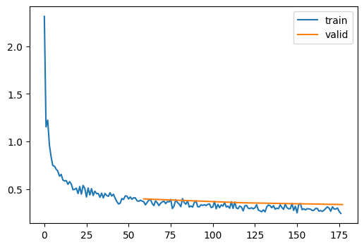

```python
# Train with cosine annealing scheduler
set_seed(42)
model = get_model(act_gr, norm=nn.BatchNorm2d).apply(iw)

# Create recorder to track LR
rec = RecorderCB(lr=_lr)

# Combine batch scheduler and recorder
xtra = [BatchSchedCB(sched), rec]

# Use PyTorch's AdamW optimizer (Adam with proper weight decay)
# cbs = [DeviceCB(), metrics, ProgressCB(plot=True), astats]
learn = TrainLearner(model, dls, F.cross_entropy, lr=2e-2, cbs=cbs+xtra, opt_func=optim.AdamW)
learn.fit(3)
```

# Weight Initialization with `partial` and `model.apply` — Explained

## The Three Lines

```
# 1. Define the initialization function
def init_weights(m, leaky=0.):
    if isinstance(m, (nn.Conv1d, nn.Conv2d, nn.Conv3d)):
        init.kaiming_normal_(m.weight, a=leaky)

# 2. Pre-fill the leaky argument using partial
iw = partial(init_weights, leaky=0.1)

# 3. Apply it to every layer in the model
model = get_model(act_gr, norm=nn.BatchNorm2d).apply(iw)
```

## Step 1: The Initialization Function

```
def init_weights(m, leaky=0.):
    if isinstance(m, (nn.Conv1d, nn.Conv2d, nn.Conv3d)):
        init.kaiming_normal_(m.weight, a=leaky)
```

This function takes a single PyTorch module `m` (a layer) and checks if it's a convolutional layer. If it is, it reinitializes that layer's weights using **Kaiming (He) initialization**.

Why? PyTorch initializes weights with its own defaults when you create a layer, but those defaults aren't always ideal. Kaiming initialization sets the weight values so that the variance of activations stays roughly constant across layers — this prevents signals from exploding or vanishing as they pass through the network.

The `a=leaky` parameter tells Kaiming initialization that we're using Leaky ReLU activations (where `a` is the negative slope). This adjusts the variance formula to account for the fact that Leaky ReLU lets some negative values through, unlike standard ReLU which zeros them out.

The `isinstance` check means this function **only touches convolutional layers** and silently skips everything else (BatchNorm, Linear, ReLU, etc.).

## Step 2: `partial` — Pre-filling an Argument

```
iw = partial(init_weights, leaky=0.1)
```

`partial` creates a new function from an existing one with some arguments already filled in. After this line:

```
# Calling iw(some_module) is exactly the same as calling:
init_weights(some_module, leaky=0.1)
```

`iw` is now a function that takes one argument (a module) and calls `init_weights` with `leaky=0.1` already set.

**Why use `partial` here?** Because `model.apply()` (which we'll see next) expects a function that takes exactly **one argument** — the module. Our `init_weights` takes two arguments (`m` and `leaky`). `partial` adapts it by baking in the `leaky=0.1` value, leaving a one-argument function that `apply` can use.

```
# Without partial — apply can't pass the leaky argument:
model.apply(init_weights)  # Would use default leaky=0., no way to change it

# With partial — leaky=0.1 is baked in:
iw = partial(init_weights, leaky=0.1)
model.apply(iw)  # Every call uses leaky=0.1
```

## Step 3: `model.apply(iw)` — Walking Through Every Layer

```
model = get_model(act_gr, norm=nn.BatchNorm2d).apply(iw)
```

First, `get_model(...)` creates the model — a neural network with multiple layers (convolutions, batch norms, activations, etc.). Then `.apply(iw)` is called on it.

`model.apply(fn)` is a built-in PyTorch method that **recursively walks through every module in the model** and calls `fn` on each one. If your model looks like:

```
Model
├── Conv2d (layer 1)
├── BatchNorm2d
├── LeakyReLU
├── Conv2d (layer 2)
├── BatchNorm2d
├── LeakyReLU
├── Conv2d (layer 3)
└── Linear
```

Then `model.apply(iw)` calls `iw` on each of these, one by one:

```
iw(Conv2d)       → isinstance check passes → reinitializes weights with Kaiming
iw(BatchNorm2d)  → isinstance check fails  → does nothing, skipped
iw(LeakyReLU)    → isinstance check fails  → does nothing, skipped
iw(Conv2d)       → isinstance check passes → reinitializes weights with Kaiming
iw(BatchNorm2d)  → isinstance check fails  → does nothing, skipped
iw(LeakyReLU)    → isinstance check fails  → does nothing, skipped
iw(Conv2d)       → isinstance check passes → reinitializes weights with Kaiming
iw(Linear)       → isinstance check fails  → does nothing, skipped
```

Only the `Conv2d` layers get their weights reinitialized. Everything else passes through untouched.

**`apply` returns the model itself**, so the whole expression `get_model(...).apply(iw)` creates the model, reinitializes its conv weights, and assigns the result to `model` — all in one line.

## The Full Chain in One View

```
partial(init_weights, leaky=0.1)
  │
  └── creates iw: a function that takes one module
                   and calls init_weights(module, leaky=0.1)

get_model(act_gr, norm=nn.BatchNorm2d)
  │
  └── creates a model with Conv2d, BatchNorm2d, LeakyReLU, Linear layers
        │
        └── .apply(iw)
              │
              ├── iw(Conv2d_1)      → Kaiming init with a=0.1
              ├── iw(BatchNorm2d_1) → skipped (not a Conv)
              ├── iw(LeakyReLU_1)   → skipped (not a Conv)
              ├── iw(Conv2d_2)      → Kaiming init with a=0.1
              ├── iw(BatchNorm2d_2) → skipped
              ├── iw(LeakyReLU_2)   → skipped
              ├── iw(Conv2d_3)      → Kaiming init with a=0.1
              └── iw(Linear)        → skipped
              │
              └── returns the model with reinitialized conv weights
```

## Why This Matters

Without proper initialization, deep networks can suffer from vanishing or exploding activations in the early stages of training. Kaiming initialization with the correct `leaky` parameter ensures that the signal variance stays stable across layers from the very first forward pass, giving the optimizer a much better starting point.

# Scheduler Callbacks — The Full Picture

## The Problem We're Solving

Up to this point in the course, every training run we've done uses a **fixed learning rate**. We pick a number like `lr=0.4` or `lr=6e-3`, and that exact same number is used for every single batch from start to finish.

But we've already seen (from our `sched_lrs` visualization) that cosine annealing gives us a smooth, decreasing learning rate that could help training. The question now is: **how do we actually plug a scheduler into our training loop?**

The challenge is that our training loop lives inside `learn.fit()` — we don't manually write the for-loop over batches. The `Learner` class handles all of that internally. So we can't just add `sched.step()` somewhere in a hand-written loop. We need a way to **inject** our scheduler logic into the Learner's existing training loop, without modifying the Learner itself.

That's exactly what **callbacks** are for.

## Quick Refresher: How Callbacks Work

The fast.ai Learner calls specific **hook points** at various stages of training. The flow looks like this:

```
learn.fit(n_epochs)
│
├── calls before_fit()  on all callbacks      ← "training is about to start"
│
├── FOR EACH EPOCH:
│   ├── FOR EACH BATCH (training):
│   │   ├── calls before_batch()              ← "a batch is about to be processed"
│   │   ├── forward pass (predictions)
│   │   ├── compute loss
│   │   ├── loss.backward()  (gradients)
│   │   ├── optimizer.step() (update weights)
│   │   ├── optimizer.zero_grad()
│   │   └── calls after_batch()               ← "batch is done"
│   │
│   ├── FOR EACH BATCH (validation):
│   │   ├── forward pass
│   │   ├── compute loss
│   │   └── calls after_batch()               ← "batch is done"
│   │
│   └── calls after_epoch()                   ← "epoch is done"
│
└── calls after_fit()                         ← "training is finished"
```

Any callback we write can define methods like `before_fit()`, `after_batch()`, `after_epoch()`, etc. The Learner will automatically call them at the right time. This is how we extend the training loop without touching the Learner code.

With that in mind, let's build our scheduler callbacks.

## Building the Scheduler Callback System

### `BaseSchedCB` — The Foundation

```
#|export
class BaseSchedCB(Callback):
    def __init__(self, sched): self.sched = sched
    def before_fit(self, learn): self.schedo = self.sched(learn.opt)
    def _step(self, learn):
        if learn.training: self.schedo.step()
```

This is the **base class** that all scheduler callbacks inherit from. Let me walk through it piece by piece.

**`#|export`** — This is a `nbdev` directive. It tells nbdev to export this class to the `miniai/sgd.py` module file when we run `nbdev_export()`. It has no effect on the code itself — it's purely a build-system instruction.

**`class BaseSchedCB(Callback):`** — We're creating a new class called `BaseSchedCB` that inherits from `Callback`. This means it can be passed into the Learner's `cbs` list, and the Learner will call its hook methods (`before_fit`, `after_batch`, etc.) at the right times.

**`def __init__(self, sched): self.sched = sched`** — The constructor takes one argument: `sched`. But here's a crucial subtlety — **`sched` is not an actual scheduler instance.** It's a **partially applied class** (a `functools.partial` object). Why? Because when we create the callback, the optimizer doesn't exist yet. The optimizer gets created inside `learn.fit()`. So we can't create the scheduler yet either (it needs the optimizer). We store the partial and create the real scheduler later in `before_fit`.

For example, `sched` might be:

[output not shown]

**`def before_fit(self, learn): self.schedo = self.sched(learn.opt)`** — This is called by the Learner right before training starts. By this point, the Learner has already created the optimizer (`learn.opt`). So NOW we can create the actual scheduler instance by calling `self.sched(learn.opt)`. This is equivalent to:

[output not shown]

We store the resulting scheduler object as `self.schedo` (the "o" stands for "object" — distinguishing the real scheduler object from the partial we stored earlier).

**`def _step(self, learn):`** — This is a helper method (the underscore prefix is a Python convention meaning "intended for internal use"). It advances the scheduler by one step, but **only during training**. The `if learn.training` check is important: during validation, we don't want to step the scheduler. Validation batches should not affect the learning rate schedule — only training batches should.

**`self.schedo.step()`** — This calls the scheduler's `step()` method, which computes the new learning rate using the cosine formula and updates the optimizer's `lr`. After this call, the next training batch will use the updated (lower) learning rate.

Notice that `BaseSchedCB` does NOT define `after_batch` or `after_epoch`. It only provides the `_step` helper. The child classes decide **when** to call it.

### `BatchSchedCB` — Step After Every Batch

```
#|export
class BatchSchedCB(BaseSchedCB):
    def after_batch(self, learn): self._step(learn)
```

This is beautifully simple. It inherits everything from `BaseSchedCB` and adds one thing: it calls `_step()` after every batch.

**`class BatchSchedCB(BaseSchedCB):`** — Inherits from `BaseSchedCB`, so it gets `__init__`, `before_fit`, and `_step` for free.

**`def after_batch(self, learn): self._step(learn)`** — The Learner calls `after_batch` after every batch (both training and validation). Inside `_step`, the `if learn.training` check ensures we only step the scheduler during training batches.

**Why step per-batch instead of per-epoch?** If we have 59 batches per epoch and train for 3 epochs, that's 177 total training batches. Stepping per-batch means the learning rate changes 177 times (smooth, gradual change). Stepping per-epoch would only change it 3 times (coarse, staircase-like change). Per-batch stepping gives a much smoother schedule.

The notebook also defines an `EpochSchedCB` later that calls `_step` in `after_epoch` instead — for schedulers that should update once per epoch.

### `HasLearnCB` — Store a Reference to the Learner

```
#|export
class HasLearnCB(Callback):
    def before_fit(self, learn): self.learn = learn
    def after_fit(self, learn): self.learn = None
```

This callback is a utility — it stores a reference to the Learner so that other code can access it outside of the standard callback methods.

**`def before_fit(self, learn): self.learn = learn`** — When training starts, save a reference to the Learner object. This is useful if some external code (like a plotting function) needs to reach into the Learner and inspect things like `learn.opt` or `learn.model`.

**`def after_fit(self, learn): self.learn = None`** — When training ends, clear the reference. This is good practice to avoid memory leaks — we don't want a stale reference to a Learner (which holds the model, data, etc.) hanging around in memory after training is done.

This callback isn't directly related to the scheduler system, but it's defined here because it's a general utility that the training infrastructure uses.

### `RecorderCB` — Record Values During Training

```
#|export
class RecorderCB(Callback):
    def __init__(self, **d): self.d = d
    def before_fit(self, learn):
        self.recs = {k:[] for k in self.d}
        self.pg = learn.opt.param_groups[0]

    def after_batch(self, learn):
        if not learn.training: return
        for k,v in self.d.items():
            self.recs[k].append(v(self))

    def plot(self):
        for k,v in self.recs.items():
            plt.plot(v, label=k)
            plt.legend()
            plt.show()
```

This callback records any values we want to track during training — most importantly, the **learning rate** — so we can plot them afterwards to verify the schedule worked correctly.

#### What Does `**d` Mean?

The `**` in a function definition is Python's "keyword argument collector." It takes **all** keyword arguments that you pass to the function and packs them into a **dictionary**. The variable name `d` is arbitrary — it could be `**kwargs` or `**anything` — but `d` is used here for brevity.

Here's what happens step by step when you write:

```
rec = RecorderCB(lr=_lr)
```

1. Python sees the keyword argument `lr=_lr`
2. The `**d` in `__init__` collects it into a dictionary: `d = {'lr': _lr}`
3. `self.d = d` stores that dictionary on the instance

So after this line, `rec.d` is:

```
{'lr': <function _lr>}
```

The **key** `'lr'` is a string (the name we chose). The **value** `_lr` is a **function object** — not the result of calling the function, but the function itself. We're storing the function so we can call it later, once per batch.

#### What About Multiple Keyword Arguments?

When we write:

```
rec = RecorderCB(lr=_lr, mom=_beta1)
```

The exact same `**d` mechanism captures BOTH keyword arguments into one dictionary:

1. Python sees two keyword arguments: `lr=_lr` and `mom=_beta1`
2. `**d` packs them into: `d = {'lr': _lr, 'mom': _beta1}`
3. `self.d = d` stores the dictionary

Now `rec.d` is:

```
{'lr': <function _lr>, 'mom': <function _beta1>}
```

We have two entries — one for learning rate, one for momentum. Each is a name paired with a function that knows how to extract that value.

#### The Full Lifecycle: From Creation to Plot

Let's trace what happens to `rec = RecorderCB(lr=_lr, mom=_beta1)` through the entire training run:

**Step 1 — Creation** (`__init__`):

```
rec = RecorderCB(lr=_lr, mom=_beta1)
# rec.d = {'lr': _lr, 'mom': _beta1}
# That's it. Just stores the functions. Nothing is recorded yet.
```

**Step 2 — Training starts** (`before_fit`):

```
# The Learner calls rec.before_fit(learn)
self.recs = {k:[] for k in self.d}
# self.recs = {'lr': [], 'mom': []}
# Creates an EMPTY list for each thing we're tracking.
# These lists will fill up during training.

self.pg = learn.opt.param_groups[0]
# Stores reference to the optimizer's param group dictionary
# so the functions _lr and _beta1 can read from it.
```

**Step 3 — After each training batch** (`after_batch`, called ~177 times):

```
# The Learner calls rec.after_batch(learn)
if not learn.training: return    # Skip validation batches

for k, v in self.d.items():
    self.recs[k].append(v(self))
```

Let's unroll this loop for our two entries:

```
# Iteration 1: k='lr', v=_lr
self.recs['lr'].append(_lr(self))
#                       ↓
#               _lr receives the RecorderCB instance (self)
#               _lr(cb) returns cb.pg['lr'] → e.g., 0.019
#               So: self.recs['lr'].append(0.019)

# Iteration 2: k='mom', v=_beta1
self.recs['mom'].append(_beta1(self))
#                        ↓
#               _beta1 receives the RecorderCB instance (self)
#               _beta1(cb) returns cb.pg['betas'][0] → e.g., 0.85
#               So: self.recs['mom'].append(0.85)
```

After this one batch, the lists look like:

```
self.recs = {
    'lr':  [0.019],
    'mom': [0.85]
}
```

After 177 training batches, they look like:

```
self.recs = {
    'lr':  [0.02, 0.01999, 0.01996, ..., 0.0001, 0.00002],    # 177 values
    'mom': [0.85, 0.8501, 0.8503,  ..., 0.949, 0.95],          # 177 values
}
```

**Step 4 — After training** (`plot`):

```
rec.plot()
# Loops over self.recs:
#   Plots the 'lr' list → smooth cosine curve from 0.02 to ~0
#   Plots the 'mom' list → inverse curve from ~0.85 to ~0.95
```

#### Why Pass Functions Instead of Just Hardcoding?

You might wonder: why not just write `self.pg['lr']` directly inside `after_batch` instead of this whole function-passing mechanism? The answer is **flexibility**. By accepting arbitrary functions via `**kwargs`, RecorderCB can record literally anything without changing a single line of its own code:

```
# Record just the LR:
rec = RecorderCB(lr=_lr)

# Record LR and momentum:
rec = RecorderCB(lr=_lr, mom=_beta1)

# Record something totally custom:
rec = RecorderCB(lr=_lr, wd=lambda cb: cb.pg['weight_decay'])
```

Each time, the same RecorderCB class handles it. The `**d` pattern makes it infinitely extensible. This is a very Pythonic design — pass behavior (functions) as data.

**`def before_fit(self, learn):`** — Called when training starts. Two things happen:

- `self.recs = {k:[] for k in self.d}` — Creates an empty list for each thing we're recording. For `RecorderCB(lr=_lr)`, this creates `{'lr': []}`. Each batch will append one value to this list.
- `self.pg = learn.opt.param_groups[0]` — Stores a reference to the optimizer's first parameter group. The `[0]` is indexing into a list, and the natural question is: why `[0]`? Why not `[1]` or some other index? To answer this, we need to understand what `param_groups` actually is.

#### What Are Parameter Groups?

When you create an optimizer, you pass it the model's parameters and a learning rate:

```
opt = optim.AdamW(model.parameters(), lr=0.02)
```

Internally, the optimizer wraps ALL those parameters into a single "parameter group" — a dictionary that bundles the parameters together with their shared hyperparameters:

```
opt.param_groups = [
    {                                           # ← This is param_groups[0]
        'params': [weight1, bias1, weight2, bias2, ...],  # ALL model parameters
        'lr': 0.02,                             # Learning rate for this group
        'betas': (0.9, 0.999),                  # Adam-specific
        'weight_decay': 0.01,                   # Weight decay for this group
        ...
    }
]
```

`param_groups` is a **list** of these dictionaries. When you create the optimizer the simple way (as we do in this notebook), there is **exactly one** dictionary in that list — everything is in one group. That's why `[0]` works: there's only one group, and it's at index 0.

#### When Would There Be More Than One Group?

In more advanced training setups, you might want **different learning rates for different parts of the model**. This is common in transfer learning, where you fine-tune a pretrained backbone with a tiny LR while training a new classification head with a larger LR:

```
opt = optim.AdamW([
    {'params': model.backbone.parameters(), 'lr': 0.0001},   # param_groups[0]
    {'params': model.head.parameters(),     'lr': 0.01},     # param_groups[1]
])
```

Now `opt.param_groups` has **two** dictionaries:

- `param_groups[0]` → backbone parameters with lr=0.0001
- `param_groups[1]` → head parameters with lr=0.01

In this case, `param_groups[0]` would only give you the backbone's LR. You'd need to look at `param_groups[1]` too if you wanted to track the head's LR.

#### Why `[0]` Is Fine For Us

In this notebook, we create the optimizer the simple way — one LR for all parameters:

```
learn = TrainLearner(model, dls, F.cross_entropy, lr=2e-2, cbs=cbs+xtra, opt_func=optim.AdamW)
```

This creates an optimizer with a single parameter group containing ALL model parameters sharing the same `lr=0.02`. So `param_groups[0]` is the only group, and it contains the LR that the scheduler is modifying. Reading `param_groups[0]['lr']` gives us exactly the learning rate that every parameter in the model is using.

If we were doing something more advanced with multiple parameter groups, we'd need to modify `RecorderCB` to track multiple groups. But for this course, one group is all we need, so `[0]` is the right choice.

**`def after_batch(self, learn):`** — Called after every batch.

- `if not learn.training: return` — Skip validation batches. We only want to record during training.
- The for-loop iterates over our recording functions. For each one, it calls the function with `self` (the RecorderCB instance) as the argument, and appends the result to the corresponding list. So `v(self)` becomes `_lr(self)`, which returns `self.pg['lr']` — the current learning rate.

**`def plot(self):`** — After training, call `rec.plot()` to visualize everything that was recorded. It creates a separate plot for each recorded value, with a legend label.

### The `_lr` Helper Function

```
def _lr(cb): return cb.pg['lr']
```

This is a tiny helper that extracts the current learning rate from a RecorderCB instance.

**`cb`** is the RecorderCB instance (passed as `self` in `v(self)` inside `after_batch`).

**`cb.pg`** is the parameter group dictionary we saved in `before_fit`.

**`cb.pg['lr']`** is the current learning rate in that parameter group. The scheduler modifies this value every time `sched.step()` is called.

The reason this is a separate function (instead of being hardcoded in RecorderCB) is **flexibility**. We can swap it out for any function. Later in the notebook, for 1cycle training, we also record momentum:

```
def _beta1(cb): return cb.pg['betas'][0]
rec = RecorderCB(lr=_lr, mom=_beta1)
```

## Putting It All Together — The Training Code

Now let's walk through the actual training code line by line.

### Setting Up the Schedule

```
tmax = 3 * len(dls.train)
```

We want the cosine schedule to span the **entire training run**. Since we're training for 3 epochs, the total number of training batches is `3 * len(dls.train)`. `len(dls.train)` returns the number of batches in one epoch (for Fashion MNIST with batch size 1024 and 60,000 training images, that's about 59 batches). So `tmax` is approximately `3 * 59 = 177`.

This means the learning rate will smoothly decrease from its starting value to 0 over exactly 177 scheduler steps — one step per training batch, covering the entire training run.

```
sched = partial(lr_scheduler.CosineAnnealingLR, T_max=tmax)
```

We create a **partial** of the CosineAnnealingLR class. This is like saying: "I want a CosineAnnealingLR with T_max=177, but I can't create it yet because I don't have the optimizer."

`partial(lr_scheduler.CosineAnnealingLR, T_max=tmax)` creates a callable that, when called with an optimizer, produces the full scheduler:

```
# Later, inside BaseSchedCB.before_fit():
self.schedo = self.sched(learn.opt)
# This becomes:
# lr_scheduler.CosineAnnealingLR(learn.opt, T_max=177)
```

### Setting Up the Training Run

```
set_seed(42)
```

Sets the random seed for reproducibility. Every random operation (weight initialization, data shuffling, dropout) will produce the same results each time we run this code. The number 42 is arbitrary — it's a convention from *The Hitchhiker's Guide to the Galaxy*.

```
model = get_model(act_gr, norm=nn.BatchNorm2d).apply(iw)
```

Creates a fresh CNN model. `get_model` is a helper from the course that builds a convolutional neural network. Let's break down the arguments:

- `act_gr` = `partial(GeneralRelu, leak=0.1, sub=0.4)` — The activation function for each layer. GeneralRelu is a leaky ReLU variant with a subtraction term (from a previous notebook).
- `norm=nn.BatchNorm2d` — Add batch normalization after each conv layer.
- `.apply(iw)` — Apply Kaiming weight initialization to all layers. `iw` = `partial(init_weights, leaky=0.1)`. The `.apply()` method walks through every layer in the model and calls the function on each one.

```
rec = RecorderCB(lr=_lr)
```

Creates a RecorderCB that will record the learning rate after every training batch. After training, we can call `rec.plot()` to see how the LR changed over time.

```
xtra = [BatchSchedCB(sched), rec]
```

Creates a list of the **extra** callbacks we want to add for this particular training run:

- `BatchSchedCB(sched)` — The scheduler callback. Will step the cosine annealing scheduler after every training batch.
- `rec` — The recorder callback. Will record the learning rate after every training batch.

```
learn = TrainLearner(model, dls, F.cross_entropy, lr=2e-2, cbs=cbs+xtra, opt_func=optim.AdamW)
```

Creates the Learner — the object that orchestrates the entire training process. Let's break down every argument:

- `model` — The CNN we just created.
- `dls` — The DataLoaders (training + validation data for Fashion MNIST).
- `F.cross_entropy` — The loss function. Cross-entropy is standard for classification tasks.
- `lr=2e-2` — The **initial** learning rate = 0.02. The cosine scheduler will decrease it from here.
- `cbs=cbs+xtra` — ALL the callbacks for this training run. `cbs` was defined earlier as `[DeviceCB(), metrics, ProgressCB(plot=True), astats]` — the standard callbacks for device management, metrics tracking, progress display, and activation statistics. We concatenate our extra callbacks to this list, giving us:

  ```
  [DeviceCB(), MetricsCB(), ProgressCB(), ActivationStats(),
   BatchSchedCB(sched), RecorderCB(lr=_lr)]
  ```

- `opt_func=optim.AdamW` — Use PyTorch's AdamW optimizer (Adam with proper decoupled weight decay) instead of our from-scratch implementations.

### The Training Run

```
learn.fit(3)
```

This single line triggers the entire training process for 3 epochs. But a LOT happens under the hood. Let me trace through exactly what occurs, focusing on how the scheduler and recorder interact with the training loop.

## What Happens When `learn.fit(3)` Runs

Here is the detailed execution flow, showing exactly when each callback fires and what it does:

### Phase 1: Initialization

```
learn.fit(3) is called
│
├── Learner creates the optimizer:
│   learn.opt = optim.AdamW(model.parameters(), lr=0.02)
│   (AdamW optimizer with initial LR = 0.02)
│
├── Learner calls before_fit() on ALL callbacks:
│   │
│   ├── DeviceCB.before_fit()
│   │   └── Moves model to GPU
│   │
│   ├── MetricsCB.before_fit()
│   │   └── Initializes metric trackers
│   │
│   ├── BatchSchedCB.before_fit(learn)          ← SCHEDULER SETUP
│   │   └── self.schedo = self.sched(learn.opt)
│   │       This creates the actual scheduler:
│   │       CosineAnnealingLR(learn.opt, T_max=177)
│   │       The scheduler reads learn.opt's LR (0.02) as the base LR.
│   │       From now on, the scheduler can modify learn.opt's LR.
│   │
│   └── RecorderCB.before_fit(learn)            ← RECORDER SETUP
│       ├── self.recs = {'lr': []}
│       │   Creates an empty list to store LR values
│       └── self.pg = learn.opt.param_groups[0]
│           Stores reference to optimizer's param group
│           (so _lr() can read the current LR later)
```

### Phase 2: Training Loop (Repeated for Each Batch)

```
FOR EACH EPOCH (3 times):
│
├── FOR EACH TRAINING BATCH (≈59 times per epoch):
│   │
│   │ ┌─────────────────────────────────────────────────┐
│   │ │         THE STANDARD TRAINING STEP              │
│   │ │                                                 │
│   │ │  1. Forward pass: predictions = model(batch)    │
│   │ │  2. Compute loss: loss = cross_entropy(pred, y) │
│   │ │  3. Backward pass: loss.backward()              │
│   │ │  4. Optimizer step: opt.step()                  │
│   │ │     └── Updates weights using current LR        │
│   │ │         (first batch: LR = 0.02)                │
│   │ │  5. Zero gradients: opt.zero_grad()             │
│   │ └─────────────────────────────────────────────────┘
│   │
│   │ ┌─────────────────────────────────────────────────┐
│   │ │         after_batch() CALLBACKS FIRE             │
│   │ │                                                 │
│   │ │  BatchSchedCB.after_batch(learn):               │
│   │ │  └── self._step(learn)                          │
│   │ │      └── learn.training is True                 │
│   │ │          └── self.schedo.step()                  │
│   │ │              Computes new LR via cosine formula  │
│   │ │              Updates opt.param_groups[0]['lr']    │
│   │ │              (e.g., 0.02 → 0.01999 → 0.01996..) │
│   │ │                                                 │
│   │ │  RecorderCB.after_batch(learn):                 │
│   │ │  └── learn.training is True                     │
│   │ │      └── _lr(self) = self.pg['lr']              │
│   │ │          Reads the LR that was just updated     │
│   │ │          Appends it to self.recs['lr']          │
│   │ │          (e.g., recs['lr'] = [0.02, 0.01999...])│
│   │ └─────────────────────────────────────────────────┘
│   │
│   │   NEXT BATCH USES THE NEW (LOWER) LEARNING RATE
│   │
│
├── FOR EACH VALIDATION BATCH:
│   │
│   │ ┌─────────────────────────────────────────────────┐
│   │ │  Forward pass only (no backward, no opt.step)   │
│   │ │                                                 │
│   │ │  after_batch() CALLBACKS FIRE                   │
│   │ │                                                 │
│   │ │  BatchSchedCB.after_batch(learn):               │
│   │ │  └── self._step(learn)                          │
│   │ │      └── learn.training is FALSE                │
│   │ │          └── Does nothing! (scheduler not stepped│
│   │ │              during validation)                  │
│   │ │                                                 │
│   │ │  RecorderCB.after_batch(learn):                 │
│   │ │  └── learn.training is FALSE                    │
│   │ │      └── return (does nothing)                  │
│   │ └─────────────────────────────────────────────────┘
```

### Phase 3: After Training

```
learn.fit(3) completes
│
└── We can now call rec.plot() to see the LR trajectory
    └── Plots self.recs['lr'] — a list of ≈177 values
        showing the smooth cosine decrease from 0.02 to ≈0
```

## The Order of Events for a Single Training Batch

Let me zoom into one specific batch to make the sequence crystal clear. Say we're on batch #50 out of 177 total:

[output not shown]

The key insight: the scheduler updates the LR **after** the optimizer has already used it for this batch. So the new LR takes effect on the **next** batch. This is the correct behavior — the scheduler decides what LR the next batch should use, based on how far along we are in training.

## How Does the Scheduler's New LR Actually Reach the Optimizer?

This is the question at the heart of the whole system, and the answer is surprisingly simple once you see it. The scheduler and the optimizer are **not** two separate, disconnected objects that somehow pass messages to each other. They are connected by a **shared dictionary in memory**.

### The Shared Dictionary: `param_groups`

When we create the optimizer, it stores its learning rate inside a data structure called `param_groups`:

```
opt = optim.AdamW(model.parameters(), lr=0.02)

# Internally, the optimizer stores:
opt.param_groups = [
    {
        'params': [weight1, bias1, weight2, bias2, ...],
        'lr': 0.02,        # ← The learning rate lives HERE
        'betas': (0.9, 0.999),
        'weight_decay': 0.01,
        ...
    }
]
```

`param_groups` is a **list of dictionaries**. Each dictionary is a "parameter group" — a bundle of parameters that share the same hyperparameters. Most models have just one parameter group (index `[0]`), so the learning rate lives at:

```
opt.param_groups[0]['lr']    # This is where the LR number lives
```

This is a plain Python dictionary, sitting in memory. It's not a copy — it's THE actual dictionary that the optimizer reads from.

### How the Optimizer Uses This Dictionary

Every time `opt.step()` is called (to update weights), the AdamW optimizer internally does something like this:

```
# Simplified view of what happens inside opt.step()
def step(self):
    for group in self.param_groups:        # Loop over param groups
        lr = group['lr']                   # ← READ the LR from the dict
        for p in group['params']:
            p.data -= lr * (computed_update)  # Use that LR to update weights
```

The optimizer **reads `group['lr']` fresh every single time** it's called. It does NOT store the learning rate separately. It does NOT cache it. Every call to `opt.step()` looks up the current value in the dictionary at that moment.

### How the Scheduler Modifies This Dictionary

When we create the scheduler, we pass it the optimizer:

```
scheduler = CosineAnnealingLR(opt, T_max=177)
```

The scheduler stores a **reference** to that same optimizer object. Not a copy — the exact same object in memory. So when the scheduler calls `step()`, it does something like this:

```
# Simplified view of what happens inside scheduler.step()
def step(self):
    new_lr = self._compute_lr()            # Cosine formula → e.g., 0.0148
    for group in self.optimizer.param_groups:
        group['lr'] = new_lr               # ← WRITE the new LR into the dict
```

The scheduler reaches into `self.optimizer.param_groups[0]['lr']` and **overwrites** the learning rate value with the newly computed one.

### The Key Insight: They Share the Same Dictionary

Here's the critical point. There is only **ONE** `param_groups` dictionary in memory. Both the optimizer and the scheduler point to it:

```
              ┌────────────────────────────────────┐
              │     param_groups[0] dictionary      │
              │                                    │
              │   'lr': 0.02  →  0.0199  →  0.0148 │  ← This value changes
              │   'params': [weight1, bias1, ...]   │
              │   'betas': (0.9, 0.999)             │
              └──────────┬──────────┬───────────────┘
                         │          │
                    READS from  WRITES to
                         │          │
                    ┌────┴────┐ ┌───┴──────┐
                    │ AdamW   │ │ Cosine   │
                    │Optimizer│ │Scheduler │
                    └─────────┘ └──────────┘
```

When the scheduler writes a new LR value into the dictionary, the optimizer automatically "sees" it on the next call to `opt.step()` — because they're both looking at the **same** dictionary. There's no message passing, no notification system, no event. It's just two objects reading and writing the same piece of memory.

### Walking Through Two Consecutive Batches

Let's make this completely concrete with two batches:

**Batch 50:**

[output not shown]

**Batch 51:**

[output not shown]

That's it. No magic. The optimizer reads the LR from a dictionary. The scheduler writes a new value into that same dictionary. The next time the optimizer reads it, it gets the updated value. The shared dictionary IS the connection between them.

### Why This Design Works So Well

This "shared mutable dictionary" design is elegant because:

1. **No coupling needed.** The optimizer doesn't know or care that a scheduler exists. It just reads `group['lr']` every time. You could change the LR by writing to the dictionary yourself (`opt.param_groups[0]['lr'] = 0.001`) and it would work exactly the same way.
2. **Any scheduler works with any optimizer.** Since all PyTorch optimizers read from `param_groups` and all schedulers write to `param_groups`, you can mix and match freely — CosineAnnealing with Adam, OneCycle with SGD, etc.
3. **The RecorderCB reads from the same place.** When our RecorderCB calls `_lr(self)` which returns `self.pg['lr']`, it's reading from that SAME dictionary. So it always sees whatever the scheduler last wrote. That's why `rec.plot()` accurately shows the cosine curve — it's reading from the single source of truth.

```
              ┌────────────────────────────────────┐
              │     param_groups[0] dictionary      │
              │                                    │
              │   'lr': 0.0148                      │
              │                                    │
              └──┬─────────┬──────────┬────────────┘
                 │         │          │
            READS from WRITES to  READS from
                 │         │          │
            ┌────┴───┐ ┌───┴────┐ ┌───┴────────┐
            │ AdamW  │ │ Cosine │ │ RecorderCB │
            │opt.step│ │ sched  │ │ _lr(self)  │
            └────────┘ └────────┘ └────────────┘
```

## Why This Design? The Motivation Behind Each Piece

### Why use a partial instead of creating the scheduler directly?

```
sched = partial(lr_scheduler.CosineAnnealingLR, T_max=tmax)
# NOT:
sched = lr_scheduler.CosineAnnealingLR(opt, T_max=tmax)
```

Because at the time we define the schedule, **the optimizer doesn't exist yet**. The Learner creates the optimizer inside `fit()`. Using a partial lets us say "I want this type of scheduler with these settings" without needing the optimizer right now. The `before_fit` callback fills in the optimizer later.

### Why split BaseSchedCB and BatchSchedCB?

Because **when** to step the scheduler is a separate concern from **how** to set it up. `BaseSchedCB` handles the setup (creating the scheduler, providing the `_step` helper). `BatchSchedCB` says "step after every batch." The notebook also defines `EpochSchedCB` that says "step after every epoch." Both share the same setup logic from `BaseSchedCB` — no code duplication.

### Why check `learn.training` in `_step`?

During validation, the Learner still calls `after_batch()` on all callbacks. But we don't want validation batches to advance the scheduler. If we did, the scheduler would step during validation too, which would:

1. Make the LR decrease faster than intended (extra steps we didn't account for)
2. Mess up the T_max calculation (we computed T_max based on training batches only)

### Why is RecorderCB separate from the scheduler?

Separation of concerns. The scheduler's job is to **change** the LR. The recorder's job is to **observe** the LR. By keeping them separate, we can:

- Use the recorder without a scheduler (to monitor a constant LR)
- Use the scheduler without a recorder (when we don't need plots)
- Record things other than LR (momentum, loss, etc.)

### Why does RecorderCB use functions like `_lr` instead of hardcoding?

Flexibility. By accepting any function via `**kwargs`, RecorderCB can record **anything**. For 1cycle training, we record both LR and momentum with:

```
rec = RecorderCB(lr=_lr, mom=_beta1)
```

No need to modify the RecorderCB class — just pass different functions.

## The Big Picture

Here's what all these pieces achieve together:

```
┌─────────────────────────────────────────────────────────────┐
│                    learn.fit(3)                              │
│                                                             │
│  ┌──────────┐    ┌──────────────┐    ┌──────────────┐      │
│  │  AdamW   │◄───│ BatchSchedCB │    │  RecorderCB  │      │
│  │ Optimizer│    │              │    │              │      │
│  │          │    │ After each   │    │ After each   │      │
│  │ lr=0.02  │    │ train batch: │    │ train batch: │      │
│  │ (changes)│    │ sched.step() │    │ record LR    │      │
│  └────┬─────┘    │ → updates    │    │ → append to  │      │
│       │          │   opt's lr   │    │   list       │      │
│       │          └──────────────┘    └──────┬───────┘      │
│       │                                     │              │
│       ▼                                     ▼              │
│  Updates model                         rec.plot()          │
│  weights each                          shows smooth        │
│  batch using the                       cosine curve        │
│  current LR                            from 0.02 → 0      │
└─────────────────────────────────────────────────────────────┘
```

The **scheduler** changes the LR. The **optimizer** uses whatever LR it currently has. The **recorder** watches and logs. The **Learner** orchestrates everything by calling callbacks at the right moments. Each piece has one job, and together they give us smooth cosine annealing with full visibility into what happened.

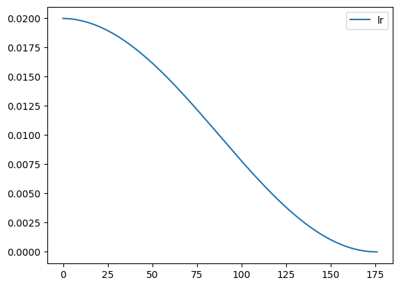

```python
# Plot the learning rate over training
rec.plot()
```

# Understanding `BatchSchedCB` and How the Scheduler Flows Through Training

## Start Here: What is `sched`?

```
tmax = epochs * len(dls.train)
sched = partial(lr_scheduler.CosineAnnealingLR, T_max=tmax)
```

`partial` is a Python tool that lets you "pre-fill" some arguments of a function, creating a new callable that remembers those arguments. So `sched` here is **not** a scheduler object — it is a frozen, half-built function call waiting for one more ingredient.

Concretely:

```
# This is what sched "remembers" internally:
sched = partial(lr_scheduler.CosineAnnealingLR, T_max=tmax)

# Calling sched(optimizer) is exactly the same as writing:
lr_scheduler.CosineAnnealingLR(optimizer, T_max=tmax)
```

The reason we use `partial` here is that we don't have the optimizer yet when we write this line. The optimizer only gets created inside `TrainLearner`. So we wrap everything we *do* know (`T_max=tmax`) into a `partial`, and hand that over. When the optimizer is ready, we just call `sched(optimizer)` to finish building the scheduler.

## How `sched` Travels Through the Callback System

Let's follow it step by step.

### Step 1 — You pass `sched` into `BatchSchedCB`

```
xtra = [BatchSchedCB(sched), rec]
```

`BatchSchedCB` has no `__init__` of its own, so Python goes up to the parent:

```
class BaseSchedCB(Callback):
    def __init__(self, sched): self.sched = sched
```

At this point, `self.sched` is still just the `partial` object — the recipe. No scheduler exists yet. The optimizer doesn't exist yet either.

### Step 2 — `learn.fit(epochs)` starts, and `before_fit` fires

The very first thing the training loop does is call `before_fit` on every callback. `BaseSchedCB.before_fit` does this:

```
def before_fit(self, learn): self.schedo = self.sched(learn.opt)
```

Now `learn.opt` exists (the AdamW optimizer was created when `TrainLearner` was set up). So this line becomes:

```
self.schedo = lr_scheduler.CosineAnnealingLR(learn.opt, T_max=tmax)
```

**This is the moment the real scheduler object comes to life.** It wraps around the optimizer and knows it needs to adjust the learning rate over `tmax` batches following a cosine curve — starting high, smoothly decaying to near zero.

### Step 3 — Every batch, `after_batch` fires

```
class BatchSchedCB(BaseSchedCB):
    def after_batch(self, learn): self._step(learn)
```

And `_step` is:

```
def _step(self, learn):
    if learn.training: self.schedo.step()
```

So after every single training batch, `self.schedo.step()` is called. The `if learn.training` guard means this does **not** happen during validation batches. The scheduler only advances during training.

But *how exactly* does `self.schedo.step()` change the learning rate? Let's dig into this properly.

## What Happens Inside `.step()` — The Mechanism Explained

This is the crucial part. Let's understand exactly why calling `.step()` changes the learning rate inside the optimizer.

### First, understand what `param_groups` is

When you create an optimizer like `optim.AdamW(model.parameters(), lr=6e-2)`, PyTorch organizes all the model's parameters into a list called `param_groups`. Each entry in this list is a dictionary that holds both the parameters themselves and their hyperparameters. You can inspect it directly:

```
optimizer.param_groups[0]
# {'params': [...all tensors...], 'lr': 0.06, 'weight_decay': 0.01, ...}
```

The key `'lr'` in that dictionary is the learning rate that the optimizer actually uses when it updates the weights. When AdamW does its update step, it reads `param_groups[0]['lr']` to know how large a step to take. This is the one and only number that matters — it is the live, active learning rate.

### Now, what does `CosineAnnealingLR` do when it wraps the optimizer?

When you call:

```
self.schedo = lr_scheduler.CosineAnnealingLR(learn.opt, T_max=tmax)
```

The scheduler does two things at construction time:

1. It stores a reference to your optimizer: `self.optimizer = optimizer`
2. It reads the current learning rate from each param group and stores it as the *base* learning rate: `self.base_lrs = [group['lr'] for group in optimizer.param_groups]`

So `base_lrs` is `[0.06]` — the starting learning rate you set. The scheduler uses this as `η_max` in the cosine formula.

### What does `.step()` actually do line-by-line?

Every call to `self.schedo.step()` does the following internally (from PyTorch source):

1. **Increments a counter** — `self.last_epoch += 1`. This tracks how many times `.step()` has been called, which is the current position along the cosine curve (`T_cur`).
2. **Calls `get_lr()`** — This computes the new learning rate using the cosine formula based on `last_epoch` and `T_max`:

```
# Simplified version of what get_lr() computes:
new_lr = eta_min + (base_lr - eta_min) * (1 + cos(π * last_epoch / T_max)) / 2
```

With `eta_min=0` (the default) and `base_lr=0.06`, this becomes:

```
new_lr = 0.06 * (1 + cos(π * last_epoch / T_max)) / 2
```

3. **Writes the result back into `param_groups`** — This is the key step. The scheduler directly overwrites `optimizer.param_groups[0]['lr']` with the newly computed value:

```
for param_group, lr in zip(self.optimizer.param_groups, computed_lrs):
    param_group['lr'] = lr
```

That's it. The scheduler reaches into the optimizer's `param_groups` dictionary and overwrites the `'lr'` field. Since the optimizer reads from this same dictionary during every weight update, the next time `optimizer.step()` runs, it automatically picks up the new learning rate.

### The proof — you can verify this yourself

You can confirm this directly with a small experiment:

```
import torch
import torch.nn as nn
import torch.optim as optim

model = nn.Linear(10, 2)
optimizer = optim.SGD(model.parameters(), lr=1.0)
scheduler = optim.lr_scheduler.CosineAnnealingLR(optimizer, T_max=10)

for step in range(10):
    scheduler.step()
    print(f"Step {step+1}: optimizer.param_groups[0]['lr'] = {optimizer.param_groups[0]['lr']:.4f}")
```

Output:

```
Step 1:  optimizer.param_groups[0]['lr'] = 0.9755
Step 2:  optimizer.param_groups[0]['lr'] = 0.9045
Step 3:  optimizer.param_groups[0]['lr'] = 0.7939
Step 4:  optimizer.param_groups[0]['lr'] = 0.6545
Step 5:  optimizer.param_groups[0]['lr'] = 0.5000
Step 6:  optimizer.param_groups[0]['lr'] = 0.3455
Step 7:  optimizer.param_groups[0]['lr'] = 0.2061
Step 8:  optimizer.param_groups[0]['lr'] = 0.0955
Step 9:  optimizer.param_groups[0]['lr'] = 0.0245
Step 10: optimizer.param_groups[0]['lr'] = 0.0000
```

You can see `param_groups[0]['lr']` change with every call to `scheduler.step()`. The value follows the cosine curve exactly — starting near 1.0 and smoothly arriving at 0.0 after `T_max=10` steps.

This is also why `RecorderCB` can track the learning rate using:

```
def _lr(cb): return cb.pg['lr']
```

`cb.pg` is just `learn.opt.param_groups[0]`, and `cb.pg['lr']` reads the live current learning rate that the scheduler has been updating after every batch.

## What CosineAnnealingLR Actually Does to the Learning Rate

`CosineAnnealingLR` decays the learning rate following half a cosine wave over `T_max` steps:

```
lr_t = eta_min + 0.5 * (base_lr - eta_min) * (1 + cos(π * t / T_max))
```

In plain terms: it starts at your initial learning rate, smoothly decreases toward zero (or `eta_min` if specified), following the shape of a cosine curve. No sudden jumps — a gradual, smooth decay.

Since `tmax = epochs * len(dls.train)`, the cosine completes exactly one half-cycle over your entire training run. Batch 1 starts at full `lr`, the final batch ends at zero.

## The Full Picture in One Flow

```
sched = partial(CosineAnnealingLR, T_max=tmax)
         └── just a recipe, no scheduler yet

BatchSchedCB(sched)
         └── stores self.sched = that recipe

learn.fit() → before_fit fires
         └── self.schedo = self.sched(learn.opt)
             = CosineAnnealingLR(optimizer, T_max=tmax)
             ← real scheduler created, stores reference to optimizer
             ← stores base_lrs = [0.06]  (read from param_groups)

learn.fit() → for each training batch:
         └── forward pass → loss → backward
             → optimizer.step()        ← uses current param_groups[0]['lr']
             → after_batch fires
             → _step(learn)
             → self.schedo.step()
                 ├── last_epoch += 1
                 ├── compute new_lr via cosine formula
                 └── param_groups[0]['lr'] = new_lr   ← written back into optimizer

         → for each validation batch:
             → after_batch fires
             → _step(learn) → if learn.training: ← False, nothing happens
             ← param_groups[0]['lr'] stays unchanged during validation
```

The mechanism is a shared dictionary: the scheduler and the optimizer both hold a reference to the same `param_groups` list. The scheduler writes to it via `.step()`, the optimizer reads from it via its own `.step()`. Because they share the same object in memory, whatever the scheduler writes, the optimizer immediately sees on its next update.

### 🎮 Interactive: watch `sched.step()` fire inside the training loop

The exact flow described above — `before_fit` creates the scheduler, then the callback decides *when* it ticks.

**What to try**

- Press **▶ Play** and follow the highlight through 2 epochs × 4 batches; every `after_batch` flashes the **sched.step()** badge and drops the lr dot down the cosine.
- **Click any box** in the loop diagram to jump straight to that moment.
- Switch to **EpochSchedCB** mode: 8 batches pass but only 2 scheduler ticks fire — the lr becomes a staircase, and T_max means epochs, not batches.
- Note `_step`'s guard `if learn.training:` — without it the lr would decay during validation too.

```python
# ============================================================================
# INTERACTIVE -- run this cell. It loads ./interactive_viz/scheduler_callback_flow.html
# at full width, sized to fit the visualization (setup cell near the top required).
# Keep the 'interactive_viz' folder in the SAME directory as this notebook.
# ============================================================================
show_viz("interactive_viz/scheduler_callback_flow.html", height="800px")
```

[interactive chart not shown]

The learning rate smoothly decreases from 0.02 to near 0 over the 3 epochs.

```python
#|export
class EpochSchedCB(BaseSchedCB):
    """
    Step the scheduler after every epoch.

    Use this for schedulers that should update per-epoch,
    like StepLR or CosineAnnealingLR with T_max = total_epochs.
    """
    def after_epoch(self, learn):
        self._step(learn)
```

| accuracy | loss | epoch | train |
| --- | --- | --- | --- |
| 0.796 | 0.552 | 0 | train |
| 0.848 | 0.416 | 0 | eval |
| 0.873 | 0.347 | 1 | train |
| 0.870 | 0.356 | 1 | eval |
| 0.893 | 0.293 | 2 | train |
| 0.879 | 0.329 | 2 | eval |

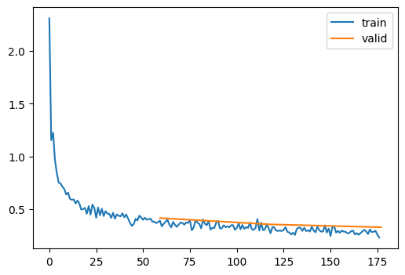

```python
# Epoch-wise cosine annealing (T_max = 3 epochs)
sched = partial(lr_scheduler.CosineAnnealingLR, T_max=3)

set_seed(42)
xtra = [EpochSchedCB(sched), rec]
# act_gr = partial(GeneralRelu, leak=0.1, sub=0.4)
model = get_model(act_gr, norm=nn.BatchNorm2d).apply(iw)
learn = TrainLearner(model, dls, F.cross_entropy, lr=2e-2, cbs=cbs+xtra, opt_func=optim.AdamW)
learn.fit(3)
```

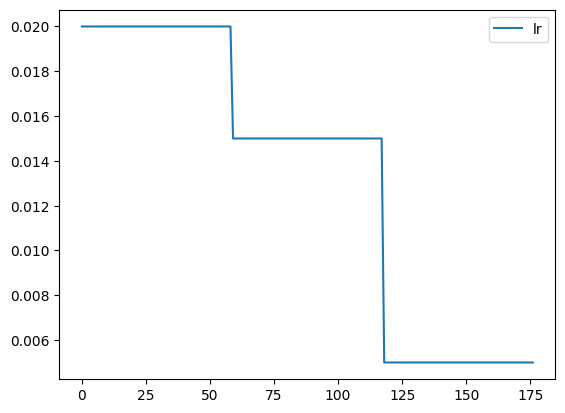

```python
# Plot LR - note it only changes at epoch boundaries
rec.plot()
```

## Part 9: 1cycle Training

The **1cycle policy** was introduced by Leslie Smith in ["Super-Convergence: Very Fast Training of Neural Networks Using Large Learning Rates"](https://arxiv.org/abs/1803.09820).

### Key Ideas

1. **Start with low LR** - Warm up the model
2. **Increase to high LR** - Fast progress through loss landscape
3. **Decrease to very low LR** - Fine-tune to converge

### The Schedule

```
LR:  low → high → very low
Mom: high → low → high
```

Notice momentum moves *opposite* to learning rate!

```python
# Function to get momentum (beta1) from Adam optimizer
def _beta1(cb):
    """Extract momentum coefficient from Adam's betas."""
    return cb.pg['betas'][0]  # betas = (beta1, beta2)

# Create recorder for both LR and momentum
rec = RecorderCB(lr=_lr, mom=_beta1)
```

| accuracy | loss | epoch | train |
| --- | --- | --- | --- |
| 0.772 | 0.648 | 0 | train |
| 0.828 | 0.497 | 0 | eval |
| 0.860 | 0.383 | 1 | train |
| 0.869 | 0.368 | 1 | eval |
| 0.884 | 0.312 | 2 | train |
| 0.879 | 0.340 | 2 | eval |
| 0.905 | 0.258 | 3 | train |
| 0.894 | 0.297 | 3 | eval |
| 0.919 | 0.221 | 4 | train |
| 0.899 | 0.279 | 4 | eval |

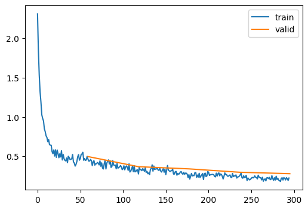

```python
# 1cycle training
set_seed(42)
lr, epochs = 6e-2, 5  # Higher LR, more epochs
model = get_model(act_gr, norm=nn.BatchNorm2d).apply(iw)

# Total steps for 1cycle
tmax = epochs * len(dls.train)

# Create OneCycleLR scheduler
# max_lr: Peak learning rate
# total_steps: Total training steps
sched = partial(lr_scheduler.OneCycleLR, max_lr=lr, total_steps=tmax)

# Combine scheduler and recorder
xtra = [BatchSchedCB(sched), rec]

# Train with AdamW
learn = TrainLearner(model, dls, F.cross_entropy, lr=lr, cbs=cbs+xtra, opt_func=optim.AdamW)
learn.fit(epochs)
```

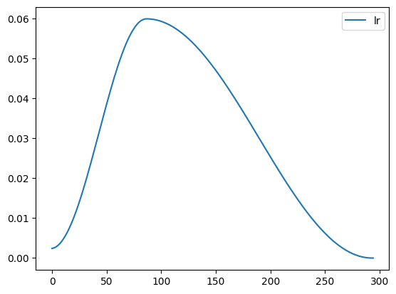

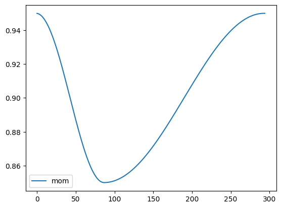

```python
# Plot LR and momentum schedules
rec.plot()
```

### Understanding the 1cycle Schedule

**Learning Rate:**

- Starts low (warmup)
- Increases to max_lr
- Decreases to very low (annealing)

**Momentum:**

- Starts high
- Decreases as LR increases
- Increases as LR decreases

**Why opposite schedules?**

- High LR + low momentum: Explore more, less committed to direction
- Low LR + high momentum: Fine-tune, smooth out noise

### 🎮 Interactive: *why* 1cycle works — escaping sharp minima

The schedule's shape is above; this shows what the shape *does* to training dynamics.

**What to try**

- Press **Train ▶**: during the high-lr phase, the ball's bounces inside the narrow pit grow until it's thrown out — then annealing settles it into the wide, flat minimum (the kind that generalizes).
- Switch to the **constant small lr** tab and replay: trapped in the sharp pit forever.
- The rail follows the phases automatically and highlights the notebook's actual 1cycle training code; stage **④** explains the inverted momentum cycle.
- Footer has the one-line math: a valley is stable only while lr < 2/curvature (a bit higher with momentum) — high lr is a filter only sharp minima fail.

```python
# ============================================================================
# INTERACTIVE -- run this cell. It loads ./interactive_viz/onecycle_dynamics.html
# at full width, sized to fit the visualization (setup cell near the top required).
# Keep the 'interactive_viz' folder in the SAME directory as this notebook.
# ============================================================================
show_viz("interactive_viz/onecycle_dynamics.html", height="800px")
```

[interactive chart not shown]

## Summary

### Optimizers

| Optimizer | Key Idea | Update Rule |
| --- | --- | --- |
| **SGD** | Basic gradient descent | `w -= lr * grad` |
| **Momentum** | Smooth with EMA of gradients | `v = β*v + (1-β)*grad; w -= lr*v` |
| **RMSProp** | Adapt LR per parameter | `s = β*s + (1-β)*grad²; w -= lr*grad/√s` |
| **Adam** | Momentum + RMSProp | Combines both with bias correction |

### Hyperparameters

| Optimizer | Typical LR | Other Hyperparameters |
| --- | --- | --- |
| SGD | 0.1 - 1.0 | weight_decay |
| Momentum | 0.1 - 2.0 | momentum (0.9) |
| RMSProp | 0.001 - 0.01 | alpha (0.99), eps |
| Adam | 0.001 - 0.01 | betas (0.9, 0.999), eps |

### Schedulers

| Scheduler | Description | When to Use |
| --- | --- | --- |
| **StepLR** | Reduce LR every N epochs | Simple decay |
| **CosineAnnealingLR** | Smooth cosine decay | General purpose |
| **OneCycleLR** | Warmup → peak → anneal | Fast training |

### Best Practices

1. **Start with Adam** - Works well out of the box
2. **Use AdamW** for weight decay - Proper decoupled weight decay
3. **Try 1cycle** for faster training - Can use higher LR
4. **Use LR finder** to find good max_lr
5. **SGD + Momentum** can achieve best final accuracy (with more tuning)

### Key Formulas

**Exponential Moving Average:** $$\text{avg}_t = \beta \cdot \text{avg}_{t-1} + (1-\beta) \cdot x_t$$

**Bias Correction:** $$\hat{\text{avg}}_t = \frac{\text{avg}_t}{1 - \beta^t}$$

**Adam Update:** $$w_{t+1} = w_t - \frac{\eta}{\sqrt{\hat{v}_t} + \epsilon} \cdot \hat{m}_t$$

## Export

```python
# import nbdev; nbdev.nbdev_export()
```